# Preproceso. E. Vazquez

# Limpieza

## Algunas funcionesd para tratar cadenas de caracteres

```r
x <- "abcdef"
x
```

```
## [1] "abcdef"
```

```r
substr(x, 2, 4)
```

```
## [1] "bcd"
```

```r
substr(x, 2, 4) <- "2222"
x
```

```
## [1] "a222ef"
```

```r
toupper(x)
```

```
## [1] "A222EF"
```

```r
strsplit(x, "")
```

```
## [[1]]
## [1] "a" "2" "2" "2" "e" "f"
```

```r
x1 <- grep("[a-z]", letters)
x1
```

```
##  [1]  1  2  3  4  5  6  7  8  9 10 11 12 13 14 15 16 17 18 19 20 21 22 23
## [24] 24 25 26
```

## Valores especiales

`is.finite()` determina si los valores son “normales”:

```r
valores <- c(1, Inf, NA, NaN, NULL)

is.finite(valores)
```

```
## [1]  TRUE FALSE FALSE FALSE
```

```r
valores[which(!is.finite(valores))] <- NA

valores
```

```
## [1]  1 NA NA NA
```

## Valores faltantes

```r
load("datos.RData")
```

### Localización

- **¿Hay valores perdidos?**

¿El *data set* tiene algún dato faltante?

```r
anyNA(temper)
```

```
## [1] TRUE
```

- **¿Cuántos faltantes hay en cada variable?**

```r
summary(temper)
```

```
##  Estacion   Temperatura
##  A   :52   Min.   :16.11
##  B   :52   1st Qu.:18.55
##  C   :51   Median :19.79
##  NA's: 1   Mean   :19.95
##            3rd Qu.:21.21
##            Max.   :32.00
##            NA's   :2
```

O bien

```r
sum(is.na(temper$Estacion))
```

```
## [1] 1
```

```r
sum(is.na(temper$Temperatura))
```

```
## [1] 2
```

```r
sum(is.na(temper))
```

```
## [1] 3
```

- **¿Cuántos casos completos tiene la hoja de datos?**

```r
complete.cases(temper)
```

```
##   [1] FALSE  TRUE FALSE  TRUE FALSE  TRUE  TRUE  TRUE  TRUE  TRUE  TRUE
##  [12]  TRUE  TRUE  TRUE  TRUE  TRUE  TRUE  TRUE  TRUE  TRUE  TRUE  TRUE
##  [23]  TRUE  TRUE  TRUE  TRUE  TRUE  TRUE  TRUE  TRUE  TRUE  TRUE  TRUE
##  [34]  TRUE  TRUE  TRUE  TRUE  TRUE  TRUE  TRUE  TRUE  TRUE  TRUE  TRUE
##  [45]  TRUE  TRUE  TRUE  TRUE  TRUE  TRUE  TRUE  TRUE  TRUE  TRUE  TRUE
##  [56]  TRUE  TRUE  TRUE  TRUE  TRUE  TRUE  TRUE  TRUE  TRUE  TRUE  TRUE
##  [67]  TRUE  TRUE  TRUE  TRUE  TRUE  TRUE  TRUE  TRUE  TRUE  TRUE  TRUE
##  [78]  TRUE  TRUE  TRUE  TRUE  TRUE  TRUE  TRUE  TRUE  TRUE  TRUE  TRUE
##  [89]  TRUE  TRUE  TRUE  TRUE  TRUE  TRUE  TRUE  TRUE  TRUE  TRUE  TRUE
## [100]  TRUE  TRUE  TRUE  TRUE  TRUE  TRUE  TRUE  TRUE  TRUE  TRUE  TRUE
## [111]  TRUE  TRUE  TRUE  TRUE  TRUE  TRUE  TRUE  TRUE  TRUE  TRUE  TRUE
## [122]  TRUE  TRUE  TRUE  TRUE  TRUE  TRUE  TRUE  TRUE  TRUE  TRUE  TRUE
## [133]  TRUE  TRUE  TRUE  TRUE  TRUE  TRUE  TRUE  TRUE  TRUE  TRUE  TRUE
## [144]  TRUE  TRUE  TRUE  TRUE  TRUE  TRUE  TRUE  TRUE  TRUE  TRUE  TRUE
## [155]  TRUE  TRUE
```

```r
ncompletos <- sum(complete.cases(temper))

cat("Nº de casos completos:", ncompletos, "\n")
```

```
## Nº de casos completos: 153
```

```r
cat("% de casos completos:", ncompletos/nrow(temper)*100, "%", "\n")
```

```
## % de casos completos: 98.07692 %
```

- **¿Dónde están los perdidos?**

¿Qué posición ocupan los valores faltantes de cada variable?

```r
which(is.na(temper$Temperatura))
```

```
## [1] 1 3
```

```r
which(is.na(temper$Estacion))
```

```
## [1] 5
```

¿Qué filas de la hoja de datos corresponden a los casos incompletos?

```r
which(!complete.cases(temper))
```

```
## [1] 1 3 5
```

### Tratamiento

#### Eliminación

- **Acciones simples sobre la hoja de datos**

Obtener una hoja de datos eliminando los casos incompletos:

```r
DF <- data.frame(x = c(1, 2, 3), y = c(0, 10, NA))
DF
```

```
##   x  y
## 1 1  0
## 2 2 10
## 3 3 NA
```

```r
na.omit(DF)
```

```
##   x  y
## 1 1  0
## 2 2 10
```

Obtener un mensaje de error en caso de que hayan perdidos en la hoja de datos:

```r
DF <- data.frame(x = c(1, 2, 3), y = c(0, 10, NA))
DF
na.fail(DF)
```

[output not shown]

```r
DF1 <- data.frame(x = c(1, 2, 3), y = c(0, 10, 20))
DF1
```

```
##   x  y
## 1 1  0
## 2 2 10
## 3 3 20
```

```r
na.fail(DF1)
```

```
##   x  y
## 1 1  0
## 2 2 10
## 3 3 20
```

- **Acciones en algunas funciones** Cuando trabajamos con una sola variable:

```r
# Si hay datos faltantes
mean(datos1$ESTATURA)
```

```
## [1] NA
```

```r
sd(datos1$ESTATURA)
```

```
## [1] NA
```

```r
# Eliminarlos
mean(datos1$ESTATURA, na.rm = T)
```

```
## [1] 172.9921
```

```r
sd(datos1$ESTATURA, na.rm = T)
```

```
## [1] 9.146362
```

- Eliminación de casos completos o eliminación por lista (`"listwise"`):

```r
attach(datos1)
```

Insertamos algunos faltantes:

```r
datos1[c(1,4,5,13,15), "ESTATURA"] <- NA
datos1[c(2,7), "PESO"] <- NA
datos1[c(2,4,5,7,11), "GASTO"] <- NA
```

Calculo de la correlacion con eliminación de perdidos por casos:

```r
round(cor(datos1[,c("PESO", "ESTATURA", "GASTO")], use="complete.obs"), 2)
```

```
##          PESO ESTATURA GASTO
## PESO     1.00     0.73  0.07
## ESTATURA 0.73     1.00  0.02
## GASTO    0.07     0.02  1.00
```

Calculo de la correlacion con eliminación de perdidos por pares:

```r
round(cor(datos1[,c("PESO", "ESTATURA", "GASTO")],use="pairwise.complete.obs"), 2)
```

```
##          PESO ESTATURA GASTO
## PESO     1.00     0.73  0.09
## ESTATURA 0.73     1.00  0.02
## GASTO    0.09     0.02  1.00
```

- Eliminación de casos incompletos o selección por variables (`"pairwise"`)

#### Imputación

Instalar y/o Cargar el paquete `Hmisc` si no lo está:

```r
if (!is.element("Hmisc", installed.packages())) {install.packages("Hmisc")}

if (!is.element("package:Hmisc", search())) {library(Hmisc)}
```

- **Para una sola variable**

```r
# Sin datos faltantes
x <- 1:5
mean(x)
```

```
## [1] 3
```

```r
median(x)
```

```
## [1] 3
```

```r
sd(x)
```

```
## [1] 1.581139
```

```r
# Con datos faltantes
x[2] <- NA
mean(x, na.rm = T)
```

```
## [1] 3.25
```

```r
median(x, na.rm = T)
```

```
## [1] 3.5
```

```r
sd(x, na.rm = T)
```

```
## [1] 1.707825
```

Imputamos la media:

```r
x.imedia <- impute(x, mean)
x.imedia
```

```
##     1     2     3     4     5
##  1.00 3.25*  3.00  4.00  5.00
```

```r
mean(x.imedia)
```

```
## [1] 3.25
```

```r
median(x.imedia)
```

```
## [1] 3.25*
```

```r
sd(x.imedia)
```

```
## [1] 1.47902
```

Imputamos la mediana:

```r
x.imedian <- impute(x, median)
x.imedian
```

```
##    1    2    3    4    5
##  1.0 3.5*  3.0  4.0  5.0
```

```r
mean(x.imedian)
```

```
## [1] 3.3
```

```r
median(x.imedian)
```

```
## [1] 3.5*
```

```r
sd(x.imedian)
```

```
## [1] 1.48324
```

Imputar una constante:

```r
x.iconst<- impute(x, 100)
x.iconst
```

```
##    1    2    3    4    5
##    1 100*    3    4    5
```

Imputar un número aleatorio de entre los de la variable:

```r
x.irnd <- impute(x, "random")
x.irnd
```

```
##  1  2  3  4  5
##  1 1*  3  4  5
```

```r
mean(x.irnd)
```

```
## [1] 2.8
```

```r
median(x.irnd)
```

```
## [1] 3
```

```r
sd(x.irnd)
```

```
## [1] 1.788854
```

## Datos anómalos

- **`boxplot()`y `boxplot.stats()`** Para determiner e identificar numéricamente los *outliers* y otros parámetros del boxplot con la función `boxplot.stats()`:

```r
# Cambiamos la hoja de datos por defecto
detach(datos1)
attach(temper)

boxplot.stats(Temperatura)
```

```
## $stats
## [1] 16.11 18.54 19.79 21.22 24.63
##
## $n
## [1] 154
##
## $conf
## [1] 19.44878 20.13122
##
## $out
## [1] 32
```

Podemos cambiar el valor del parámetro `coef`para determinar el intervalo de datos no anómalos:

```r
boxplot.stats(temper$Temperatura, coef=10)
```

```
## $stats
## [1] 16.11 18.54 19.79 21.22 32.00
##
## $n
## [1] 154
##
## $conf
## [1] 19.44878 20.13122
##
## $out
## numeric(0)
```

Gráficamente:

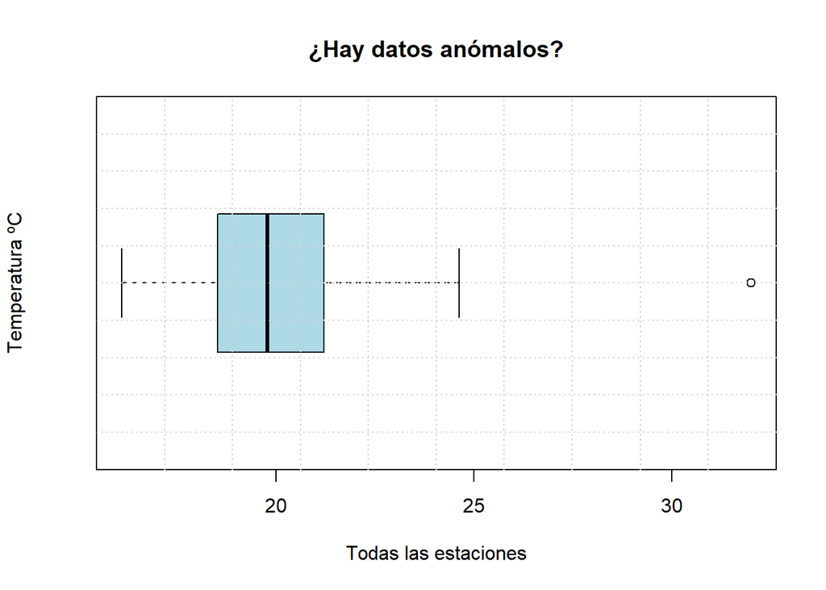

```r
boxplot(temper$Temperatura, xlab="Todas las estaciones", ylab="Temperatura ºC", main="¿Hay datos anómalos?", col="lightblue", horizontal = T)
grid(nx = 10, col = "lightgrey", lty = "dotted")
```

La función ìdentify()` llamada despues de un gráfico de caja resulta puede resultar útil para identificar anómalos (y cualquier otro punto sobre un gráfico):

Datos anómalos por `Estacion`:

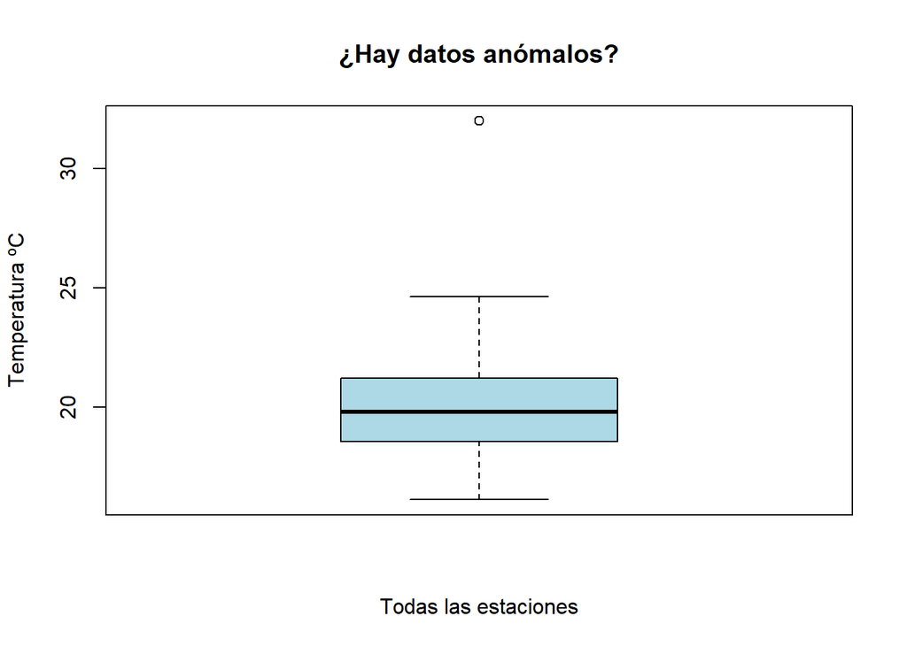

```
## integer(0)
```

```r
boxplot(temper$Temperatura, xlab="Todas las estaciones", ylab="Temperatura ºC", main="¿Hay datos anómalos?", col="lightblue")


identify(rep(1,length(temper$Temperatura)), temper$Temperatura, temper$Estacion)
```

Datos anómalos por caso:

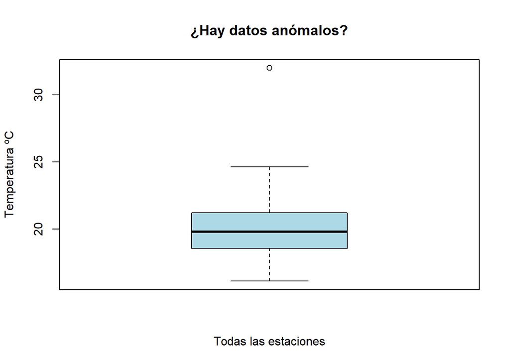

```
## integer(0)
```

```r
boxplot(temper$Temperatura, xlab="Todas las estaciones", ylab="Temperatura ºC", main="¿Hay datos anómalos?", col="lightblue")


identify(rep(1,length(temper$Temperatura)), temper$Temperatura, rownames(temper))
```

- **`qqnorm()`y `qqline()`** Otra herramienta de detección consiste en dibujar los datos sobre papel probabilístico normal y luego los puntos teóricos de probabilidad suponiendo que los datos siguen una distribución normal:

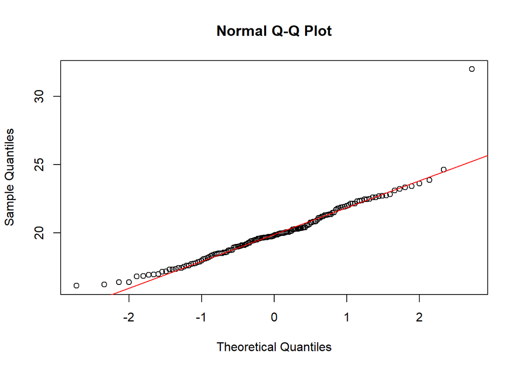

```r
qqnorm(Temperatura)
qqline(Temperatura, distribution = qnorm, col = "red")
```

# Integración

## Filtrado

### Filtrado de variables

Creamos un nuevo data frame que contenga solo las variables EDAD, ESTATURA y PESO:

```r
nuevos1 <- datos1[,c("EDAD", "ESTATURA", "PESO")]
head(nuevos1)
```

```
##   EDAD ESTATURA PESO
## 1   20       NA   54
## 2   20      164   NA
## 3   19      185   70
## 4   19       NA   63
## 5   20       NA   63
## 6   23      159   54
```

Con la función `subset()`:

```r
nuevos1 <- subset(datos1, select = c("EDAD", "ESTATURA", "PESO"))
head(nuevos1)
```

```
##   EDAD ESTATURA PESO
## 1   20       NA   54
## 2   20      164   NA
## 3   19      185   70
## 4   19       NA   63
## 5   20       NA   63
## 6   23      159   54
```

### Filtrado de casos

Filtrar los casos correspondientes a mujeres de más de 20 años:

```r
nuevos2 <- subset(datos1, SEXO=="mujer" & EDAD>20)
head(nuevos2)
```

```
##     SEXO EDAD MES ESTATURA PESO PROVINCIA X ACCESOS    TIPO  GASTO COMPRA1
## 6  mujer   23  10      159   54  Alicante 5      65    yoga 10.902      no
## 7  mujer   21   5      160   NA  Alicante 7      45    yoga     NA      no
## 8  mujer   21   4      155   48  Alicante 3      30 fitness 10.097      no
## 10 mujer   22   4      172   59  Alicante 7      45    yoga  8.964      no
## 12 mujer   21   9      160   49  Alicante 4      30          5.856      no
## 14 mujer   21   9      163   56  Alicante 3      45 fitness  9.617      no
##    GASTO2 COMPRA2
## 6  12.780      si
## 7   9.619      si
## 8   6.895      si
## 10 10.015      si
## 12 11.422      si
## 14 11.842      si
```

### Filtrado de variables y casos

```r
nuevos3 <- subset(datos1, select = c("EDAD", "ESTATURA", "PESO"), SEXO=="mujer" & EDAD>20)
head(nuevos3)
```

```
##    EDAD ESTATURA PESO
## 6    23      159   54
## 7    21      160   NA
## 8    21      155   48
## 10   22      172   59
## 12   21      160   49
## 14   21      163   56
```

## Ordenación y *rankings*

Ordenar todos los casos de un data frame en función de una variable (p.e. EDAD) en orden creciente:

```r
orden1 <- datos1[order(datos1$EDAD, decreasing = F),]
head(orden1)
```

```
##     SEXO EDAD MES ESTATURA PESO PROVINCIA X ACCESOS     TIPO  GASTO
## 3  varon   19  NA      185   70           5      30  pilates  8.541
## 4  varon   19  12       NA   63           8      20  fitness     NA
## 15 mujer   19  12       NA   53  Alicante 8      20     yoga 10.519
## 29 varon   19  12      175   65  Alicante 3      15 aparatos     NA
## 45 varon   19   1      179   67 Castellon 7      30  pilates  5.544
## 91 varon   19  12      180   60    Teruel 0       4  pilates 10.319
##    COMPRA1 GASTO2 COMPRA2
## 3       no 10.426      no
## 4       no 12.320      no
## 15      no 13.121      si
## 29      no  6.150      si
## 45      no  7.241      no
## 91      no 12.247      no
```

Ordenar todos los casos de un data frame en función de una variable (p.e. EDAD) en orden decreciente:

```r
orden2 <- datos1[order(datos1$EDAD, decreasing = T),]
head(orden2)
```

```
##      SEXO EDAD MES ESTATURA PESO PROVINCIA X ACCESOS     TIPO  GASTO
## 18  varon   32  10      181   67  Alicante 7      35 aparatos 12.450
## 52  varon   27   4      183   66 Castellon 7      24     yoga  9.023
## 19  varon   26   2      175   63  Alicante 7      16  pilates 11.204
## 92  varon   25   8      170   67    Teruel 5      20     yoga 13.382
## 131 varon   25   7      174   77  Valencia 2      45  fitness  9.656
## 58  varon   24  12      172   89 Castellon 1      30     yoga  9.929
##     COMPRA1 GASTO2 COMPRA2
## 18       no  9.967      si
## 52       no  7.898      no
## 19       no 12.755      si
## 92       no 11.324      no
## 131      no  8.608      no
## 58       no 10.792      no
```

Ordenar todos los casos de un data frame en función de dos variable (p.e. MES y EDAD) orden creciente:

```r
orden3 <- datos1[order(datos1$MES, datos1$EDAD), ]
head(orden3)
```

```
##     SEXO EDAD MES ESTATURA PESO PROVINCIA X ACCESOS     TIPO  GASTO
## 45 varon   19   1      179   67 Castellon 7      30  pilates  5.544
## 21 varon   20   1      171   75  Alicante 8      15     yoga 13.391
## 33 mujer   20   1      161   48 Castellon 5      60  pilates 10.464
## 42 varon   20   1      183   76 Castellon 5      15  pilates  8.346
## 61 mujer   20   1      168   61    Teruel 7       7 aparatos  7.942
## 20 varon   21   1      180   72  Alicante 3      15 aparatos 12.289
##    COMPRA1 GASTO2 COMPRA2
## 45      no  7.241      no
## 21      no 11.128      si
## 33      si 11.458      no
## 42      no  5.672      no
## 61      no  8.970      no
## 20      no  8.427      si
```

## Agregación y combinación

Añadir casos y nuevas variables y combinar conjuntos de datos. Funciones `merge()`, `rbind()` y `cbind()`

```r
## Simulamos una nueva variable que contiene la precipitación media en l/m2
attach(temper)
x<-rnorm(length(Temperatura), 300, 50)

## Añadimos la nueva variable al data frame
temper$Precipitacion<-x

head(temper)
```

```
##   Estacion Temperatura Precipitacion
## 1        A          NA      311.0538
## 2        A       32.00      343.4757
## 3        B          NA      283.6816
## 4        B       22.73      368.5792
## 5     <NA>       23.42      361.3086
## 6        C       19.56      251.9228
```

```r
## O bien
temper1<-cbind(temper, x)

head(temper1)
```

```
##   Estacion Temperatura Precipitacion        x
## 1        A          NA      311.0538 311.0538
## 2        A       32.00      343.4757 343.4757
## 3        B          NA      283.6816 283.6816
## 4        B       22.73      368.5792 368.5792
## 5     <NA>       23.42      361.3086 361.3086
## 6        C       19.56      251.9228 251.9228
```

```r
detach(temper)

#### Añadir casos (horizontal)
attach(datos1)

## Creamos dos grupos de datos a partir de datos1
muestra1<-datos1[1:5,]
muestra2<-datos1[6:10,]

## Combinamos los casos de ambos data frames
muestra<-rbind(muestra1, muestra2)
```

# Transformaciones

## Escalado

Estandarizar las variables ESTATURA y PESO y añadirlas al dataset datos1:

```r
datos1$est.norm <- scale(datos1$ESTATURA, center = T, scale = T)

datos1$pes.norm <- scale(datos1$PESO, center = T, scale = T)

head(datos1$est.norm)
```

```
##            [,1]
## [1,]         NA
## [2,] -0.9831301
## [3,]  1.3128648
## [4,]         NA
## [5,]         NA
## [6,] -1.5297955
```

```r
head(datos1$pes.norm)
```

```
##            [,1]
## [1,] -1.1806563
## [2,]         NA
## [3,]  0.3357560
## [4,] -0.3276744
## [5,] -0.3276744
## [6,] -1.1806563
```

Veamos un resumen:

```r
summary(datos1[,c("ESTATURA", "PESO", "est.norm", "pes.norm")])
```

```
##     ESTATURA          PESO           est.norm.V1         pes.norm.V1
##  Min.   :152.0   Min.   :45.00   Min.   :-2.295127   Min.   :-2.0336382
##  1st Qu.:165.2   1st Qu.:58.00   1st Qu.:-0.846464   1st Qu.:-0.8015532
##  Median :174.0   Median :67.00   Median : 0.110201   Median : 0.0514287
##  Mean   :173.0   Mean   :66.46   Mean   : 0.000000   Mean   : 0.0000000
##  3rd Qu.:179.0   3rd Qu.:74.00   3rd Qu.: 0.656866   3rd Qu.: 0.7148591
##  Max.   :198.0   Max.   :90.00   Max.   : 2.734195   Max.   : 2.2312714
##  NA's   :5       NA's   :2       NA's   :5           NA's   :2
```

## Transformación logarítmica

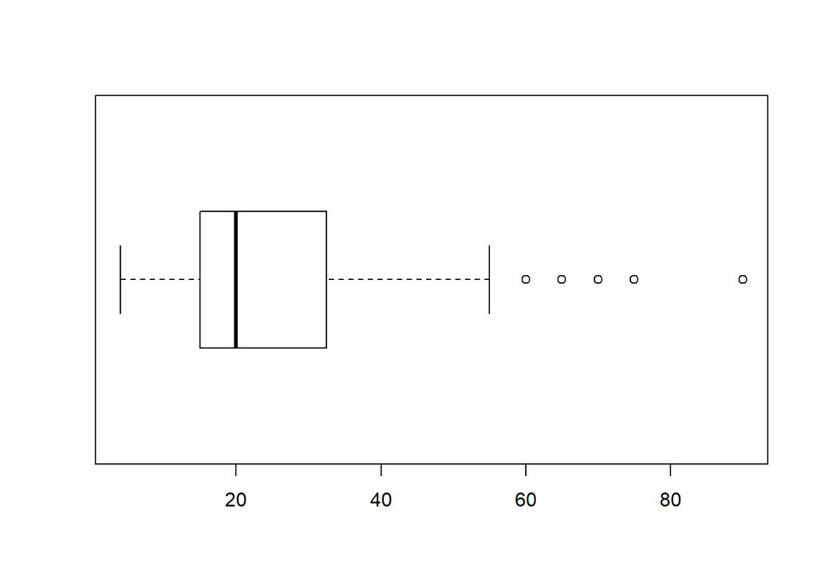

```r
# Verificar la asimetría positiva de la variable ACCESOS
boxplot(datos1$ACCESOS, horizontal = T)
```

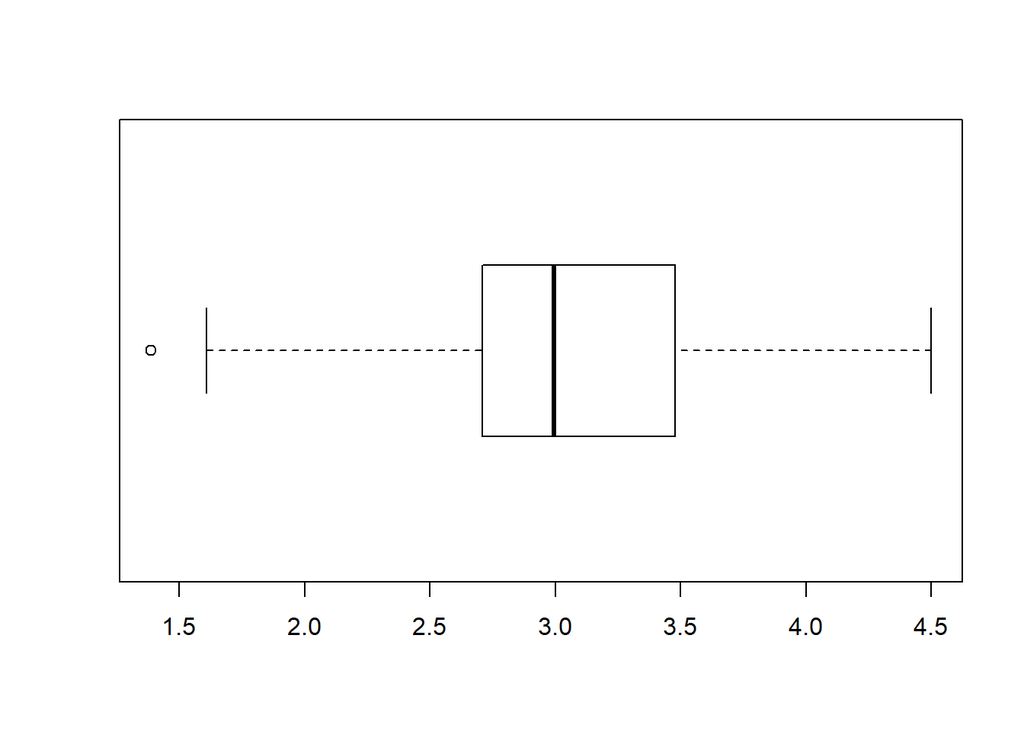

```r
# Transformación logarítmica
y<-log(datos1$ACCESOS, exp(1))

# Verificar la nueva forma d ela distribución
boxplot(y, horizontal = T)
```

## Discretización

Discretizar con 5 tramos de estatura:

```r
est.disc <- cut(datos1$ESTATURA, breaks = 5)
head(est.disc)
```

```
## [1] <NA>      (161,170] (180,189] <NA>      <NA>      (152,161]
## Levels: (152,161] (161,170] (170,180] (180,189] (189,198]
```

Diferencia de usar la variable discretizada o sin transformación:

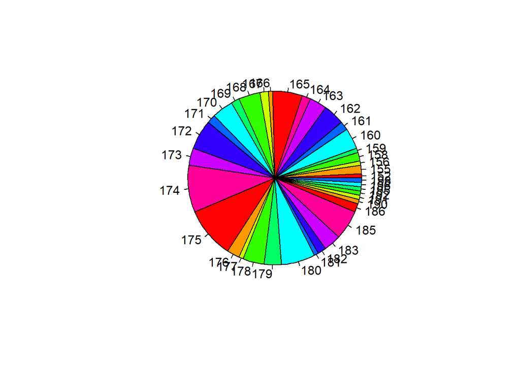

```r
pie(table(datos1$ESTATURA), col = rainbow(10))
```

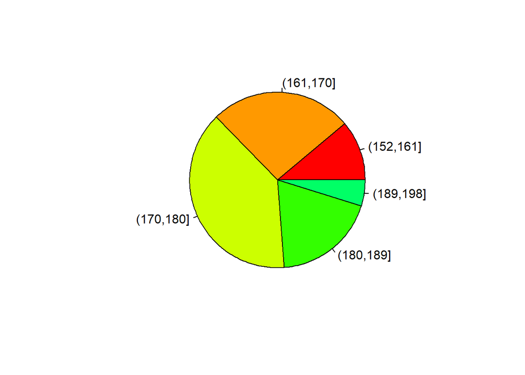

```r
pie(table(est.disc), col = rainbow(10))
```

# Reducción mediante ACP

## Paquetes

Cargar y/o instalar los necesarios

```r
if (!is.element("corpcor", installed.packages())) {install.packages("corpcor")}

if (!is.element("psych", installed.packages())) {install.packages("psych")}

if (!is.element("GPArotation", installed.packages())) {install.packages("GPArotation")}

if (!is.element("FactoMineR", installed.packages())) {install.packages("FactoMineR")}

## Cargar paquetes
library(corpcor)
library(GPArotation)
library(psych)
library(FactoMineR)
```

## Datos

Leer archivo de datos, visualizar y verificar contenido

```r
load("RAQ.RData")
objects()
```

```
##  [1] "datos1"     "DF"         "DF1"        "est.disc"   "muestra"
##  [6] "muestra1"   "muestra2"   "ncompletos" "nuevos1"    "nuevos2"
## [11] "nuevos3"    "orden1"     "orden2"     "orden3"     "raqDatos"
## [16] "temper"     "temper1"    "valores"    "x"          "x.iconst"
## [21] "x.imedia"   "x.imedian"  "x.irnd"     "x1"         "y"
```

```r
str(raqDatos)
```

```
## 'data.frame':    2571 obs. of  23 variables:
##  $ Q01: int  4 5 4 3 4 4 4 4 3 4 ...
##  $ Q02: int  5 5 3 5 5 5 3 4 3 2 ...
##  $ Q03: int  2 2 4 5 3 3 3 3 5 2 ...
##  $ Q04: int  4 3 4 2 4 4 4 4 2 3 ...
##  $ Q05: int  4 4 2 3 4 2 4 4 1 4 ...
##  $ Q06: int  4 4 5 3 3 2 4 4 3 5 ...
##  $ Q07: int  3 4 4 2 3 2 4 4 1 4 ...
##  $ Q08: int  5 4 4 4 4 4 4 4 1 4 ...
##  $ Q09: int  5 1 4 4 2 2 3 2 3 3 ...
##  $ Q10: int  4 4 4 2 4 3 4 4 3 4 ...
##  $ Q11: int  5 4 3 4 4 4 4 4 1 4 ...
##  $ Q12: int  4 3 3 4 3 2 4 3 1 3 ...
##  $ Q13: int  4 5 4 4 3 3 4 4 1 4 ...
##  $ Q14: int  4 3 2 3 4 3 4 4 1 5 ...
##  $ Q15: int  4 2 4 3 4 1 4 3 1 4 ...
##  $ Q16: int  3 3 3 3 4 4 4 4 1 3 ...
##  $ Q17: int  5 4 4 4 4 3 4 4 1 4 ...
##  $ Q18: int  4 4 3 2 3 1 4 4 1 4 ...
##  $ Q19: int  3 3 5 4 3 5 3 2 4 3 ...
##  $ Q20: int  4 2 2 2 2 1 4 3 1 3 ...
##  $ Q21: int  4 2 3 2 4 3 4 4 1 4 ...
##  $ Q22: int  4 2 4 2 2 5 2 2 3 2 ...
##  $ Q23: int  1 4 4 3 2 2 2 2 3 2 ...
```

```r
summary(raqDatos)
```

```
##       Q01             Q02             Q03             Q04
##  Min.   :1.000   Min.   :1.000   Min.   :1.000   Min.   :1.000
##  1st Qu.:3.000   1st Qu.:4.000   1st Qu.:3.000   1st Qu.:3.000
##  Median :4.000   Median :5.000   Median :3.000   Median :3.000
##  Mean   :3.626   Mean   :4.377   Mean   :3.415   Mean   :3.214
##  3rd Qu.:4.000   3rd Qu.:5.000   3rd Qu.:4.000   3rd Qu.:4.000
##  Max.   :5.000   Max.   :5.000   Max.   :5.000   Max.   :5.000
##       Q05             Q06             Q07             Q08
##  Min.   :1.000   Min.   :1.000   Min.   :1.000   Min.   :1.000
##  1st Qu.:3.000   1st Qu.:3.000   1st Qu.:2.000   1st Qu.:3.000
##  Median :3.000   Median :4.000   Median :3.000   Median :4.000
##  Mean   :3.278   Mean   :3.773   Mean   :3.076   Mean   :3.763
##  3rd Qu.:4.000   3rd Qu.:5.000   3rd Qu.:4.000   3rd Qu.:4.000
##  Max.   :5.000   Max.   :5.000   Max.   :5.000   Max.   :5.000
##       Q09             Q10             Q11             Q12
##  Min.   :1.000   Min.   :1.000   Min.   :1.000   Min.   :1.000
##  1st Qu.:2.000   1st Qu.:3.000   1st Qu.:3.000   1st Qu.:2.000
##  Median :3.000   Median :4.000   Median :4.000   Median :3.000
##  Mean   :3.154   Mean   :3.719   Mean   :3.745   Mean   :2.841
##  3rd Qu.:4.000   3rd Qu.:4.000   3rd Qu.:4.000   3rd Qu.:3.000
##  Max.   :5.000   Max.   :5.000   Max.   :5.000   Max.   :5.000
##       Q13             Q14             Q15             Q16
##  Min.   :1.000   Min.   :1.000   Min.   :1.000   Min.   :1.000
##  1st Qu.:3.000   1st Qu.:3.000   1st Qu.:3.000   1st Qu.:3.000
##  Median :4.000   Median :3.000   Median :3.000   Median :3.000
##  Mean   :3.551   Mean   :3.124   Mean   :3.234   Mean   :3.121
##  3rd Qu.:4.000   3rd Qu.:4.000   3rd Qu.:4.000   3rd Qu.:4.000
##  Max.   :5.000   Max.   :5.000   Max.   :5.000   Max.   :5.000
##       Q17             Q18             Q19             Q20
##  Min.   :1.000   Min.   :1.000   Min.   :1.000   Min.   :1.000
##  1st Qu.:3.000   1st Qu.:3.000   1st Qu.:3.000   1st Qu.:2.000
##  Median :4.000   Median :4.000   Median :4.000   Median :2.000
##  Mean   :3.533   Mean   :3.431   Mean   :3.708   Mean   :2.376
##  3rd Qu.:4.000   3rd Qu.:4.000   3rd Qu.:5.000   3rd Qu.:3.000
##  Max.   :5.000   Max.   :5.000   Max.   :5.000   Max.   :5.000
##       Q21             Q22             Q23
##  Min.   :1.000   Min.   :1.000   Min.   :1.000
##  1st Qu.:2.000   1st Qu.:2.000   1st Qu.:2.000
##  Median :3.000   Median :3.000   Median :2.000
##  Mean   :2.829   Mean   :3.112   Mean   :2.566
##  3rd Qu.:4.000   3rd Qu.:4.000   3rd Qu.:3.000
##  Max.   :5.000   Max.   :5.000   Max.   :5.000
```

```r
View(raqDatos)
```

Datos por defecto

```r
attach(raqDatos)
```

## Preparar datos de entrada

Obtener la matriz de correlación R

```r
raqR<-cor(raqDatos)
```

## Adecuación muestral

Comprobarque las variables no correlacionan ni demasiado poco,ni mucho (r>0.3 y r<0.9)

### Examinar la matriz R

```r
dim(raqDatos)
```

```
## [1] 2571   23
```

```r
round(raqR, 2)
```

```
##       Q01   Q02   Q03   Q04   Q05   Q06   Q07   Q08   Q09   Q10   Q11
## Q01  1.00 -0.10 -0.34  0.44  0.40  0.22  0.31  0.33 -0.09  0.21  0.36
## Q02 -0.10  1.00  0.32 -0.11 -0.12 -0.07 -0.16 -0.05  0.31 -0.08 -0.14
## Q03 -0.34  0.32  1.00 -0.38 -0.31 -0.23 -0.38 -0.26  0.30 -0.19 -0.35
## Q04  0.44 -0.11 -0.38  1.00  0.40  0.28  0.41  0.35 -0.12  0.22  0.37
## Q05  0.40 -0.12 -0.31  0.40  1.00  0.26  0.34  0.27 -0.10  0.26  0.30
## Q06  0.22 -0.07 -0.23  0.28  0.26  1.00  0.51  0.22 -0.11  0.32  0.33
## Q07  0.31 -0.16 -0.38  0.41  0.34  0.51  1.00  0.30 -0.13  0.28  0.34
## Q08  0.33 -0.05 -0.26  0.35  0.27  0.22  0.30  1.00  0.02  0.16  0.63
## Q09 -0.09  0.31  0.30 -0.12 -0.10 -0.11 -0.13  0.02  1.00 -0.13 -0.12
## Q10  0.21 -0.08 -0.19  0.22  0.26  0.32  0.28  0.16 -0.13  1.00  0.27
## Q11  0.36 -0.14 -0.35  0.37  0.30  0.33  0.34  0.63 -0.12  0.27  1.00
## Q12  0.35 -0.19 -0.41  0.44  0.35  0.31  0.42  0.25 -0.17  0.25  0.34
## Q13  0.35 -0.14 -0.32  0.34  0.30  0.47  0.44  0.31 -0.17  0.30  0.42
## Q14  0.34 -0.16 -0.37  0.35  0.32  0.40  0.44  0.28 -0.12  0.25  0.33
## Q15  0.25 -0.16 -0.31  0.33  0.26  0.36  0.39  0.30 -0.19  0.30  0.36
## Q16  0.50 -0.17 -0.42  0.42  0.39  0.24  0.39  0.32 -0.19  0.29  0.37
## Q17  0.37 -0.09 -0.33  0.38  0.31  0.28  0.39  0.59 -0.04  0.22  0.59
## Q18  0.35 -0.16 -0.38  0.38  0.32  0.51  0.50  0.28 -0.15  0.29  0.37
## Q19 -0.19  0.20  0.34 -0.19 -0.17 -0.17 -0.27 -0.16  0.25 -0.13 -0.20
## Q20  0.21 -0.20 -0.32  0.24  0.20  0.10  0.22  0.18 -0.16  0.08  0.26
## Q21  0.33 -0.20 -0.42  0.41  0.33  0.27  0.48  0.30 -0.14  0.19  0.35
## Q22 -0.10  0.23  0.20 -0.10 -0.13 -0.17 -0.17 -0.08  0.26 -0.13 -0.16
## Q23  0.00  0.10  0.15 -0.03 -0.04 -0.07 -0.07 -0.05  0.17 -0.06 -0.09
##       Q12   Q13   Q14   Q15   Q16   Q17   Q18   Q19   Q20   Q21   Q22
## Q01  0.35  0.35  0.34  0.25  0.50  0.37  0.35 -0.19  0.21  0.33 -0.10
## Q02 -0.19 -0.14 -0.16 -0.16 -0.17 -0.09 -0.16  0.20 -0.20 -0.20  0.23
## Q03 -0.41 -0.32 -0.37 -0.31 -0.42 -0.33 -0.38  0.34 -0.32 -0.42  0.20
## Q04  0.44  0.34  0.35  0.33  0.42  0.38  0.38 -0.19  0.24  0.41 -0.10
## Q05  0.35  0.30  0.32  0.26  0.39  0.31  0.32 -0.17  0.20  0.33 -0.13
## Q06  0.31  0.47  0.40  0.36  0.24  0.28  0.51 -0.17  0.10  0.27 -0.17
## Q07  0.42  0.44  0.44  0.39  0.39  0.39  0.50 -0.27  0.22  0.48 -0.17
## Q08  0.25  0.31  0.28  0.30  0.32  0.59  0.28 -0.16  0.18  0.30 -0.08
## Q09 -0.17 -0.17 -0.12 -0.19 -0.19 -0.04 -0.15  0.25 -0.16 -0.14  0.26
## Q10  0.25  0.30  0.25  0.30  0.29  0.22  0.29 -0.13  0.08  0.19 -0.13
## Q11  0.34  0.42  0.33  0.36  0.37  0.59  0.37 -0.20  0.26  0.35 -0.16
## Q12  1.00  0.49  0.43  0.33  0.41  0.33  0.49 -0.27  0.30  0.44 -0.17
## Q13  0.49  1.00  0.45  0.34  0.36  0.41  0.53 -0.23  0.20  0.37 -0.20
## Q14  0.43  0.45  1.00  0.38  0.42  0.35  0.50 -0.25  0.23  0.40 -0.17
## Q15  0.33  0.34  0.38  1.00  0.45  0.37  0.34 -0.21  0.21  0.30 -0.17
```

[output cut: 17 more lines]

```
## Q09  0.17
## Q10 -0.06
## Q11 -0.09
## Q12 -0.05
## Q13 -0.05
## Q14 -0.05
## Q15 -0.06
## Q16 -0.08
## Q17 -0.09
## Q18 -0.08
## Q19  0.12
## Q20 -0.03
## Q21 -0.07
## Q22  0.23
## Q23  1.00
```

Más útil gráficamente. r debe ser tipo matrix.

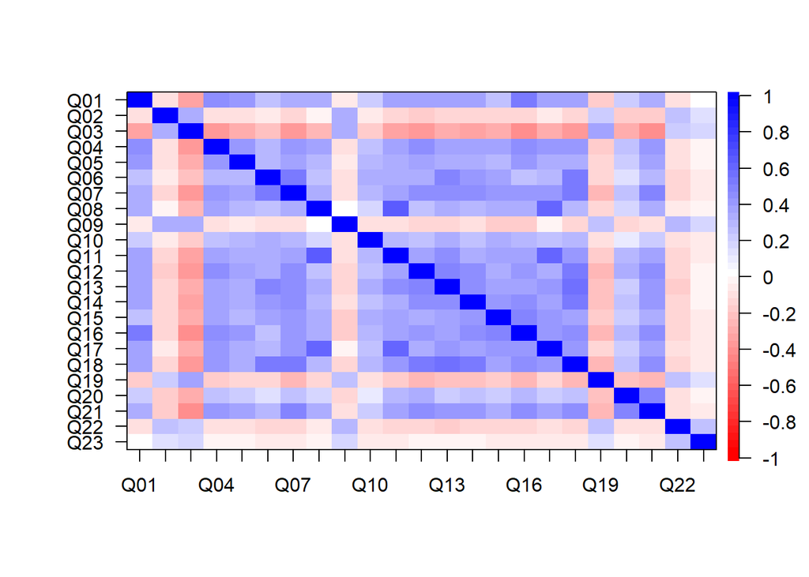

```r
 cor.plot(raqR)
```

### Evaluar el valor del determinante de R

```r
det(raqR)
```

```
## [1] 0.0005271037
```

### Realizar **Test de Bartlett**. Contrastar la H0 de que R=I (r<0.3).

Si podemos aceptar esta hipótesis, nuestros datos no son adecuados para el AF. Debemos obtener p-valores < 0.05 (alfa)

```r
alfa<-0.05
bartlett.res<-cortest.bartlett(raqR, dim(raqDatos)[1])
if (bartlett.res[2]<alfa) {print("No hay evidencia para suponer poca relación. Los datos son adecuados")} else print("Los datos NO son adecuados para este análisis")
```

```
## [1] "No hay evidencia para suponer poca relación. Los datos son adecuados"
```

El test se puede hacer a partir de las variables originales `cortest.bartlett(raqDatos)`.

### Índice Kaiser-Meyer-Olkin (KMO).

Contrastar que r<0.9 y examinar la matriz antimagen.

```r
# Llamada a kmo
raqKMO <- KMO(raqDatos)

# Llamada a kmo by G. Jay Kerns, Ph.D., Youngstown State University (http://tolstoy.newcastle.edu.au/R/e2/help/07/08/22816.html)
# Cargar a KMO
source("kmo.R")

raq.kmo <- kmo(raqDatos)
raq.kmo
```

```
## $overall
## [1] 0.9302245
##
## $report
## [1] "The KMO test yields a degree of common variance marvelous."
##
## $individual
##       Q01       Q02       Q03       Q04       Q05       Q06       Q07
## 0.9297610 0.8747754 0.9510378 0.9553403 0.9600892 0.8913314 0.9416800
##       Q08       Q09       Q10       Q11       Q12       Q13       Q14
## 0.8713055 0.8337295 0.9486858 0.9059338 0.9548324 0.9482270 0.9671722
##       Q15       Q16       Q17       Q18       Q19       Q20       Q21
## 0.9404402 0.9336439 0.9306205 0.9479508 0.9407021 0.8890514 0.9293369
##       Q22       Q23
## 0.8784508 0.7663994
```

[output cut: 244 more lines]

Gráficamente la matriz anti-imagen

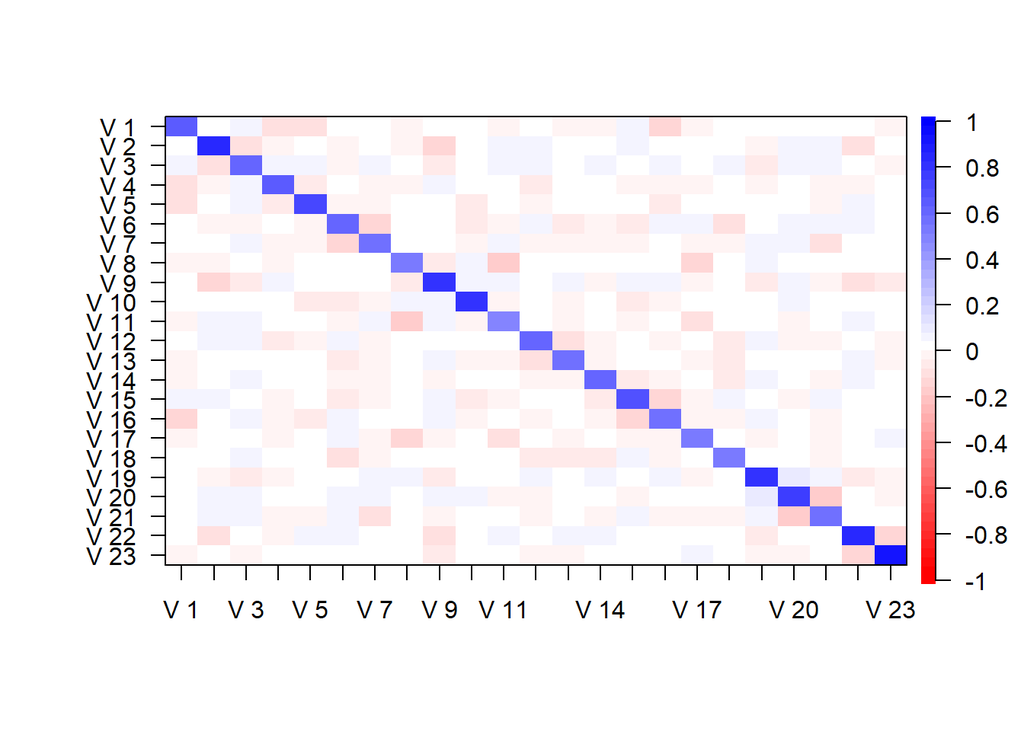

```r
cor.plot(raq.kmo$AIS)
```

## Extracción y selección de componentes

Mediante la funcion **`principal()`** Inicialmente extraemos tantas Componentes como variables:

```r
# Número de componentes
ncomp <- dim(raqDatos)[2]
```

### Modelo 1

Tantas Componentes como variables.

```r
### Primer modelo. Modelo inicial sin rotación
mcp1<- principal(raqR, nfactors = ncomp, rotate = "none")
# O bien mcp1<- principal(raqDatos, nfactors = ncomp, rotate = "none")

mcp1
```

```
## Principal Components Analysis
## Call: principal(r = raqR, nfactors = ncomp, rotate = "none")
## Standardized loadings (pattern matrix) based upon correlation matrix
##       PC1   PC2   PC3   PC4   PC5   PC6   PC7   PC8   PC9  PC10  PC11
## Q01  0.59  0.18 -0.22  0.12 -0.40 -0.11 -0.22 -0.08  0.01 -0.10  0.11
## Q02 -0.30  0.55  0.15  0.01 -0.03 -0.38  0.19 -0.39  0.01 -0.12  0.30
## Q03 -0.63  0.29  0.21 -0.07  0.02  0.00  0.01 -0.05  0.20  0.10  0.15
## Q04  0.63  0.14 -0.15  0.15 -0.20 -0.12 -0.06  0.11 -0.11 -0.01 -0.03
## Q05  0.56  0.10 -0.07  0.14 -0.42 -0.17 -0.06  0.11  0.24  0.09 -0.30
## Q06  0.56  0.10  0.57 -0.05  0.17  0.01  0.00  0.05  0.00  0.00 -0.13
## Q07  0.69  0.04  0.25  0.10  0.17 -0.08  0.05  0.03 -0.08  0.13 -0.27
## Q08  0.55  0.40 -0.32 -0.42  0.15  0.10 -0.07 -0.04  0.01 -0.05 -0.09
## Q09 -0.28  0.63 -0.01  0.10  0.17 -0.27 -0.01 -0.03  0.16  0.32 -0.22
## Q10  0.44  0.03  0.36 -0.10 -0.34  0.22  0.44 -0.03  0.37 -0.22 -0.11
## Q11  0.65  0.25 -0.21 -0.40  0.13  0.18 -0.01  0.03  0.10 -0.14  0.00
## Q12  0.67 -0.05  0.05  0.25  0.04 -0.08 -0.14  0.08  0.01 -0.11  0.19
## Q13  0.67  0.08  0.28 -0.01  0.13  0.03 -0.21  0.05  0.08 -0.22  0.24
## Q14  0.66  0.02  0.20  0.14  0.08 -0.03 -0.10 -0.06 -0.14  0.16  0.08
## Q15  0.59  0.01  0.12 -0.11 -0.07  0.29  0.32 -0.12 -0.27  0.41  0.15
## Q16  0.68  0.01 -0.14  0.08 -0.32  0.00  0.12 -0.14 -0.19  0.15  0.16
## Q17  0.64  0.33 -0.21 -0.34  0.10  0.05 -0.02  0.03 -0.04  0.02  0.01
## Q18  0.70  0.03  0.30  0.13  0.15 -0.09 -0.10  0.06 -0.06 -0.12  0.05
## Q19 -0.43  0.39  0.10 -0.01 -0.15  0.07  0.05  0.68  0.02  0.16  0.29
## Q20  0.44 -0.21 -0.40  0.30  0.33 -0.01  0.34  0.03  0.33  0.02  0.21
## Q21  0.66 -0.06 -0.19  0.28  0.24 -0.15  0.18  0.10  0.12  0.08 -0.02
## Q22 -0.30  0.47 -0.12  0.38  0.07  0.12  0.31  0.12 -0.41 -0.39 -0.19
## Q23 -0.14  0.37 -0.02  0.51  0.02  0.62 -0.28 -0.22  0.18  0.08  0.00
##      PC12  PC13  PC14  PC15  PC16  PC17  PC18  PC19  PC20  PC21  PC22
## Q01 -0.12  0.30 -0.25  0.18  0.12 -0.05 -0.17  0.16 -0.01 -0.21  0.05
## Q02  0.27 -0.02  0.01 -0.24 -0.05 -0.08  0.00  0.01 -0.02 -0.02  0.03
## Q03  0.03  0.10  0.13  0.40 -0.06  0.43  0.08  0.09  0.05  0.01  0.00
## Q04  0.34 -0.32 -0.17  0.12  0.31  0.19  0.05 -0.21  0.04  0.09 -0.02
## Q05  0.16  0.12  0.48 -0.07 -0.08 -0.04  0.01 -0.04  0.00 -0.02  0.02
## Q06  0.20  0.24 -0.03  0.08  0.20 -0.14  0.05  0.09 -0.07  0.04 -0.32
## Q07  0.20  0.04 -0.22  0.00 -0.23  0.03 -0.15  0.20  0.16  0.14  0.24
## Q08  0.03 -0.01  0.04 -0.04  0.03  0.10  0.07  0.12 -0.15  0.06  0.16
## Q09 -0.37 -0.17 -0.07  0.12  0.11 -0.19 -0.02 -0.08 -0.03  0.04 -0.01
## Q10 -0.21 -0.17 -0.15 -0.07  0.03  0.07 -0.01  0.00  0.04 -0.03  0.02
## Q11  0.03  0.02  0.03 -0.02  0.07 -0.05  0.07  0.07 -0.18  0.06  0.00
## Q12 -0.07 -0.45  0.17  0.09 -0.10 -0.08  0.04  0.36  0.00 -0.04 -0.10
```

[output cut: 46 more lines]

```
## Proportion Explained  0.03 0.03 0.03 0.03 0.02 0.02 0.02 0.02 0.02 0.02
## Cumulative Proportion 0.75 0.78 0.80 0.83 0.85 0.88 0.90 0.92 0.94 0.95
##                       PC21 PC22 PC23
## SS loadings           0.38 0.36 0.33
## Proportion Var        0.02 0.02 0.01
## Cumulative Var        0.97 0.99 1.00
## Proportion Explained  0.02 0.02 0.01
## Cumulative Proportion 0.97 0.99 1.00
##
## Mean item complexity =  5
## Test of the hypothesis that 23 components are sufficient.
##
## The root mean square of the residuals (RMSR) is  0
##
## Fit based upon off diagonal values = 1
```

¿Cuántos componentes extraemos?

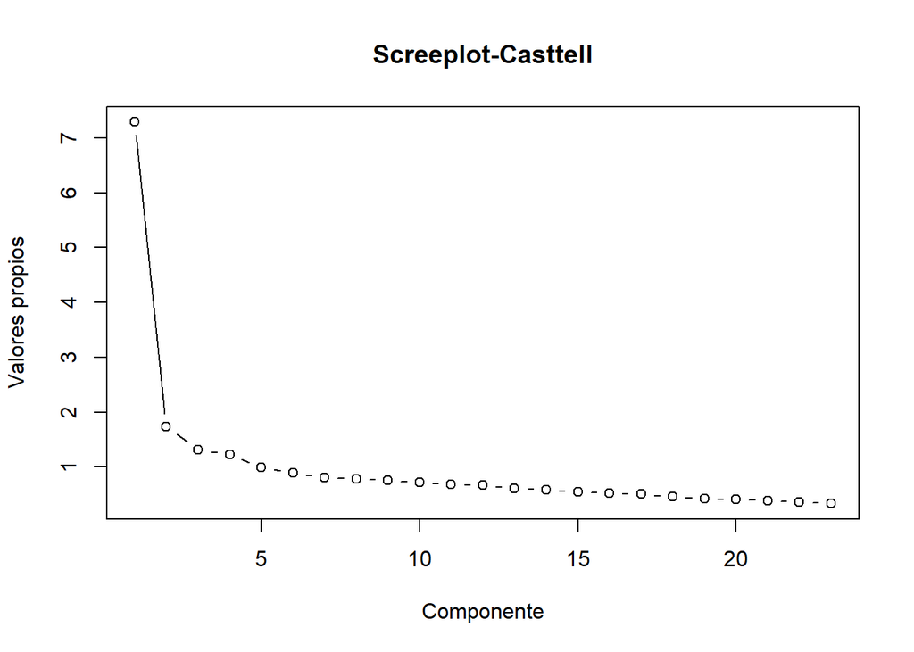

```r
# Selección de componentes a mantener. Scree plot
plot(mcp1$values, type = "b", ylab = "Valores propios", xlab = "Componente", main = "Screeplot-Casttell")
```

### Modelo 2

4 componentes

```r
## Segundo modelo. Retenemos 4 componentes sin rotción
#######################################################
ncomp <- 4
mcp2 <- principal(raqR, ncomp, rotate = "none")

# La funcion devuelve los resultados del PCA en una lista
# Podemos acceder de manera individual a cada elemento:

# Comunalidades
mcp2$communality
```

```
##       Q01       Q02       Q03       Q04       Q05       Q06       Q07
## 0.4346477 0.4137525 0.5297160 0.4685890 0.3430498 0.6539317 0.5452943
##       Q08       Q09       Q10       Q11       Q12       Q13       Q14
## 0.7394635 0.4844805 0.3347726 0.6896049 0.5133281 0.5358284 0.4882649
##       Q15       Q16       Q17       Q18       Q19       Q20       Q21
## 0.3779918 0.4870822 0.6828085 0.5973378 0.3432423 0.4839965 0.5499069
##       Q22       Q23
## 0.4635443 0.4121913
```

```r
# Valores propios
mcp2$values
```

```
##  [1] 7.2900471 1.7388287 1.3167515 1.2271982 0.9878779 0.8953304 0.8055604
##  [8] 0.7828199 0.7509712 0.7169577 0.6835877 0.6695016 0.6119976 0.5777377
## [15] 0.5491875 0.5231504 0.5083962 0.4559399 0.4238036 0.4077909 0.3794799
## [22] 0.3640223 0.3330618
```

```r
# Matriz de cargas o pesos
mcp2$loadings
```

```
##
## Loadings:
##     PC1    PC2    PC3    PC4
## Q01  0.586  0.175 -0.215  0.119
## Q02 -0.303  0.548  0.146
## Q03 -0.629  0.290  0.213
## Q04  0.634  0.144 -0.149  0.153
## Q05  0.556  0.101         0.137
## Q06  0.562         0.571
## Q07  0.685         0.252  0.103
## Q08  0.549  0.401 -0.323 -0.417
## Q09 -0.284  0.627         0.103
## Q10  0.437         0.363 -0.103
## Q11  0.652  0.245 -0.209 -0.400
## Q12  0.669                0.248
## Q13  0.673         0.278
## Q14  0.656         0.198  0.135
## Q15  0.593         0.117 -0.113
## Q16  0.679        -0.138
## Q17  0.643  0.330 -0.210 -0.342
## Q18  0.701         0.298  0.125
## Q19 -0.427  0.390
## Q20  0.436 -0.205 -0.404  0.297
## Q21  0.658        -0.187  0.282
## Q22 -0.302  0.465 -0.116  0.378
## Q23 -0.144  0.366         0.507
##
##                  PC1   PC2   PC3   PC4
## SS loadings    7.290 1.739 1.317 1.227
## Proportion Var 0.317 0.076 0.057 0.053
## Cumulative Var 0.317 0.393 0.450 0.503
```

```r
# Rotación
mcp2$rotation
```

```
## [1] "none"
```

```r
# Medida del ajuste
mcp2$fit.off
```

```
## [1] 0.9645252
```

```r
## Obtencion de los residuos del modelo 2
residuos<-factor.residuals(raqR, mcp2$loadings)
resid.2 <- residuos
```

### Modelo 3

2 componentes

```r
## Tercer modelo. Retenemos 2 componentes sin rotación
#######################################################

ncomp <- 2
mcp3 <- principal(raqR, ncomp, rotate = "none")

## Obtencion de los residuos del modelo 3
resid.3 <- factor.residuals(raqR, mcp3$loadings)
```

Análisis de residuos

```r
## Ajuste del modelo. Residuos. SRMR
# funcion residual.stats (Andy Field, Jeremy Miles, and Z.F., 2012. Discovering statistics using R, SAGE Publications)
source("residual.stats.R")

residual.stats(residuos)
```

```
## Root means squared residual =  0.05549286
## Number of absolute residuals > 0.05 =  91
## Proportion of absolute residuals > 0.05 =  0.3596838
```

En el nuevo modelo, en total, considerando las 2 componentes principales, se explica un 39% de la varianza total, menor que el modelo de 4 componentes, obviamente. Además, el índice de ajuste ha empeorado. En principio nos quedaríamos con el modelo 2 de 4 componentes.

## Rotación

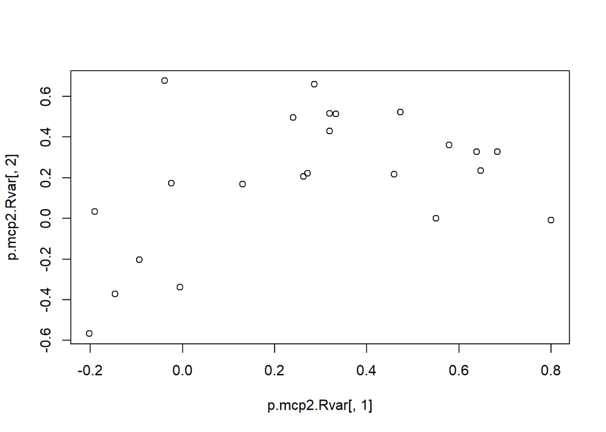

```r
########################################################
# Rotacion ortogonal varimax del modelo 2 (4 componentes)
########################################################
ncomp <- 4
mcp2.RVar <- principal(raqR, ncomp, rotate = "varimax")

p.mcp2.Rvar <- matrix(mcp2.RVar$loadings, 23,4)
colnames(p.mcp2.Rvar) <- c("CP1", "CP2", "CP3", "CP4")
plot(p.mcp2.Rvar[,1], p.mcp2.Rvar[,2])
```

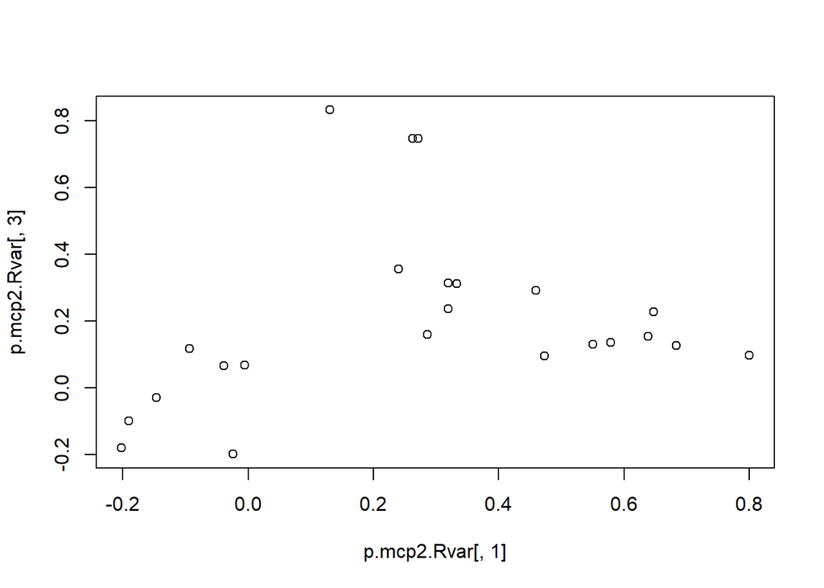

```r
plot(p.mcp2.Rvar[,1], p.mcp2.Rvar[,3])
```

```r
# Rotacion ortogonal varimax del modelo 3 (2 componentes)
########################################################
ncomp <- 2
mcp3.RVar <- principal(raqR, ncomp, rotate = "varimax")
```

## Ajuste del modelo. Comparaciones

Vamos a comparar los modelos 2 y 3 según su ajuste. Funciones **`residual.stats`** y **`factor.residuals`**.

- Modelo 2: 4 componentes sin rotar

```r
# Modelo 2: 4 componentes sin rotar
resid.2 <- factor.residuals(raqR, mcp2$loadings)
stats.resid.2 <- residual.stats(resid.2)
```

```
## Root means squared residual =  0.05549286
## Number of absolute residuals > 0.05 =  91
## Proportion of absolute residuals > 0.05 =  0.3596838
```

```r
mcp2$fit.off
```

```
## [1] 0.9645252
```

- Modelo 3: 2 componentes sin rotar

```r
# Modelo 3: 2 componentes sin rotar
resid.3 <- residuos
stats.resid.3 <- residual.stats(resid.3)
```

```
## Root means squared residual =  0.05549286
## Number of absolute residuals > 0.05 =  91
## Proportion of absolute residuals > 0.05 =  0.3596838
```

```r
mcp3$fit.off
```

```
## [1] 0.9533968
```

- Modelo 4: 4 componentes rotacion Varimax

```r
# Modelo 4: 4 componentes rotacion Varimax
resid.2.Rvar <- factor.residuals(raqR, mcp2.RVar$loadings)
stats.resid.2.Rvar <- residual.stats(resid.2.Rvar)
```

```
## Root means squared residual =  0.05549286
## Number of absolute residuals > 0.05 =  91
## Proportion of absolute residuals > 0.05 =  0.3596838
```

```r
mcp2.RVar$fit.off
```

```
## [1] 0.9645252
```

- Modelo 5: 2 componentes rotacion Varimax

```r
# Modelo 5: 2 componentes rotacion Varimax
resid.3.Rvar <- factor.residuals(raqR, mcp3.RVar$loadings)
stats.resid.3 <- residual.stats(resid.3.Rvar)
```

```
## Root means squared residual =  0.06360403
## Number of absolute residuals > 0.05 =  114
## Proportion of absolute residuals > 0.05 =  0.4505929
```

[figure not shown]

```r
mcp3.RVar$fit.off
```

```
## [1] 0.9533968
```

Efectivamente, el modelo de 4 componentes tiene un mejor ajuste.

## Interpretación del modelo

Usamos la función **`print.psych()`**.

```r
print.psych(mcp2, cut = 0.3, sort = T)
```

```
## Principal Components Analysis
## Call: principal(r = raqR, nfactors = ncomp, rotate = "none")
## Standardized loadings (pattern matrix) based upon correlation matrix
##     item   PC1   PC2   PC3   PC4   h2   u2 com
## Q18   18  0.70                   0.60 0.40 1.4
## Q07    7  0.69                   0.55 0.45 1.3
## Q16   16  0.68                   0.49 0.51 1.1
## Q13   13  0.67                   0.54 0.46 1.4
## Q12   12  0.67                   0.51 0.49 1.3
## Q21   21  0.66                   0.55 0.45 1.6
## Q14   14  0.66                   0.49 0.51 1.3
## Q11   11  0.65             -0.40 0.69 0.31 2.2
## Q17   17  0.64  0.33       -0.34 0.68 0.32 2.4
## Q04    4  0.63                   0.47 0.53 1.3
## Q03    3 -0.63                   0.53 0.47 1.7
## Q15   15  0.59                   0.38 0.62 1.2
## Q01    1  0.59                   0.43 0.57 1.6
## Q05    5  0.56                   0.34 0.66 1.2
## Q08    8  0.55  0.40 -0.32 -0.42 0.74 0.26 3.5
## Q10   10  0.44        0.36       0.33 0.67 2.1
## Q20   20  0.44       -0.40       0.48 0.52 3.2
## Q19   19 -0.43  0.39             0.34 0.66 2.1
## Q09    9        0.63             0.48 0.52 1.5
## Q02    2 -0.30  0.55             0.41 0.59 1.7
## Q22   22 -0.30  0.47        0.38 0.46 0.54 2.8
## Q06    6  0.56        0.57       0.65 0.35 2.1
## Q23   23        0.37        0.51 0.41 0.59 2.0
##
##                        PC1  PC2  PC3  PC4
## SS loadings           7.29 1.74 1.32 1.23
## Proportion Var        0.32 0.08 0.06 0.05
## Cumulative Var        0.32 0.39 0.45 0.50
## Proportion Explained  0.63 0.15 0.11 0.11
## Cumulative Proportion 0.63 0.78 0.89 1.00
##
## Mean item complexity =  1.8
## Test of the hypothesis that 4 components are sufficient.
##
## The root mean square of the residuals (RMSR) is  0.06
##
## Fit based upon off diagonal values = 0.96
```

## Puntuaciones factoriales

```r
ncomp <- 4
mcp2 <- principal(raqR, ncomp, rotate = "none", scores = T)
```

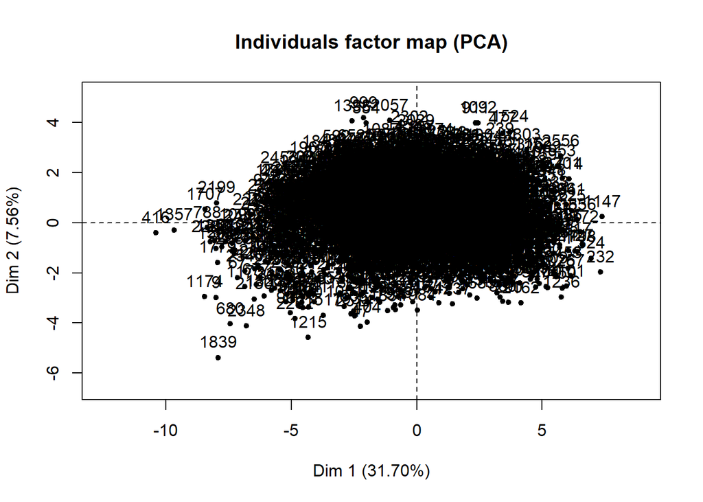

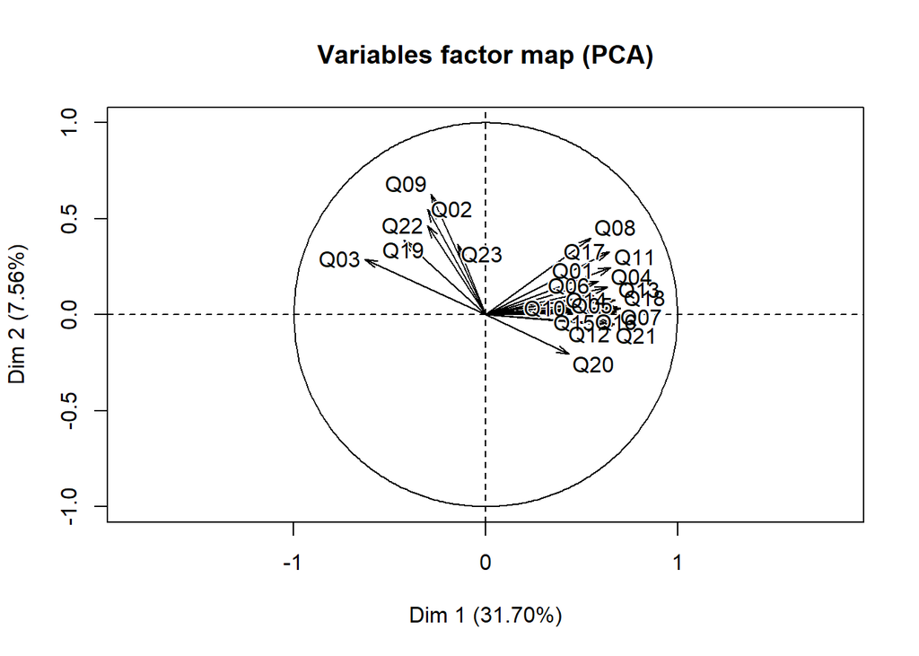

```r
# Uso de FactoMineR
result <- PCA(raqDatos)
```

```r
detach(raqDatos)
```

# Verificación de hipótesis

```r
# Ejemplo ESTATURA
attach(datos1)
## Resumen de estadísticos
summary(ESTATURA)
```

```
##    Min. 1st Qu.  Median    Mean 3rd Qu.    Max.    NA's
##   152.0   165.2   174.0   173.0   179.0   198.0       5
```

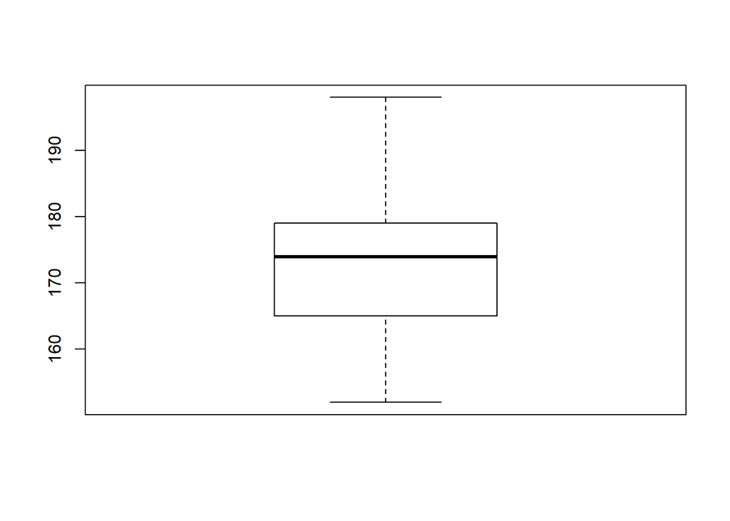

```r
boxplot(ESTATURA)
```

```r
boxplot.stats(ESTATURA)
```

```
## $stats
## [1] 152 165 174 179 198
##
## $n
## [1] 126
##
## $conf
## [1] 172.0294 175.9706
##
## $out
## integer(0)
```

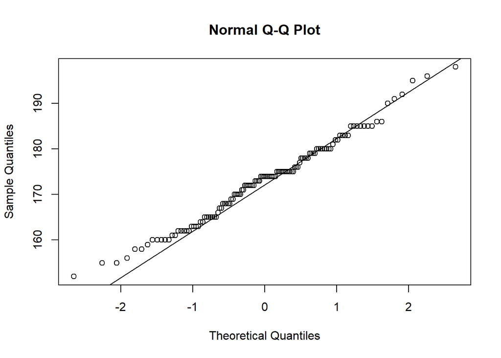

```r
qqnorm(ESTATURA)
qqline(ESTATURA)
```

```r
detach(datos1)


## Temperatura recogidas por 3 estaciones meteorológicas
## Data set "temper". Archivo "datos.RData"
attach(temper)
## Resumen de estadísticos
summary(Temperatura)
```

```
##    Min. 1st Qu.  Median    Mean 3rd Qu.    Max.    NA's
##   16.11   18.55   19.79   19.95   21.21   32.00       2
```

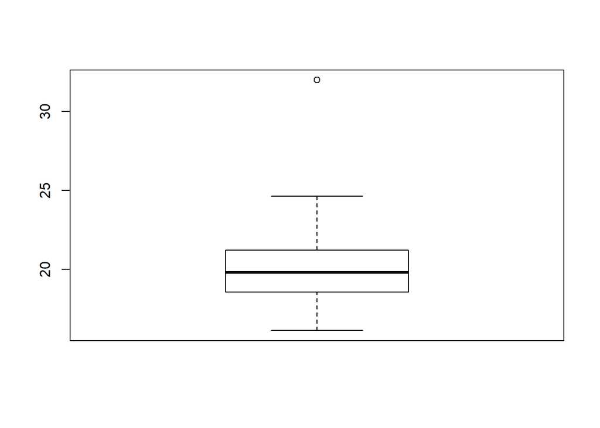

```r
boxplot(Temperatura)
```

```r
boxplot.stats(Temperatura)
```

```
## $stats
## [1] 16.11 18.54 19.79 21.22 24.63
##
## $n
## [1] 154
##
## $conf
## [1] 19.44878 20.13122
##
## $out
## [1] 32
```

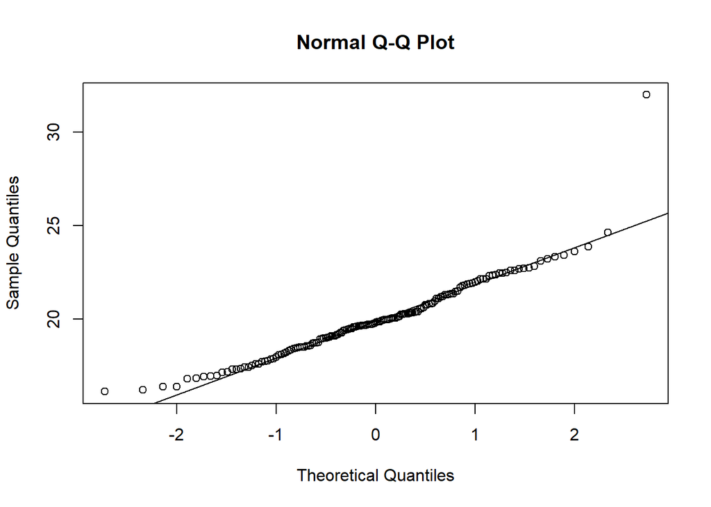

```r
qqnorm(Temperatura)
qqline(Temperatura)
```

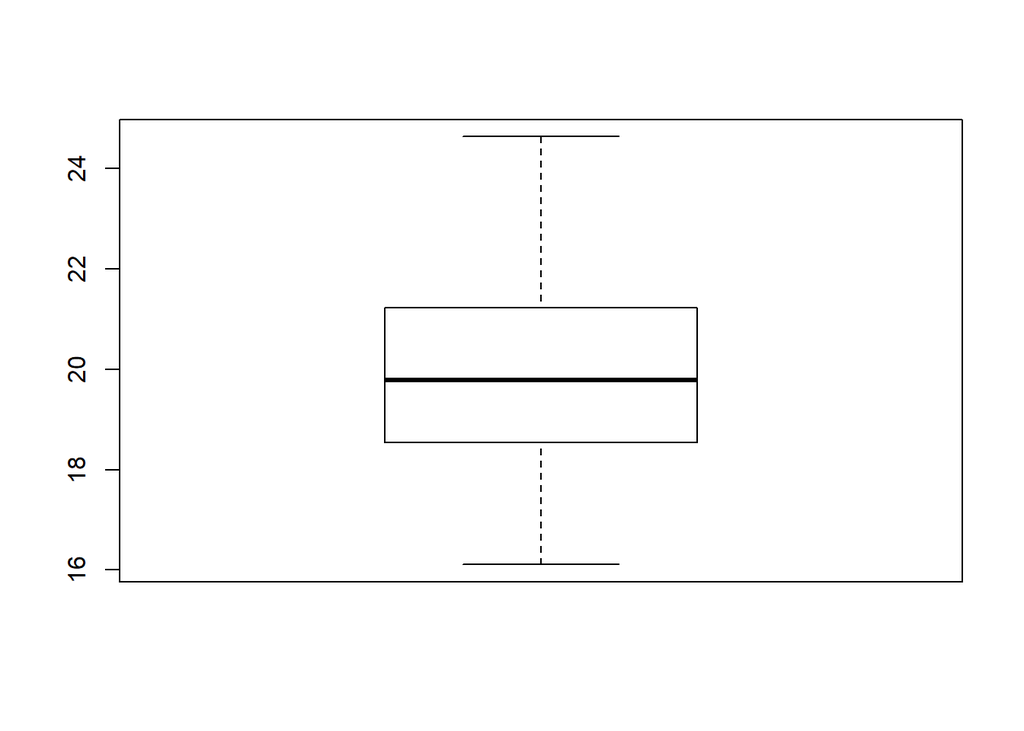

```r
# Spongamos que hay un dato anomalo que es un error y lo corregimos
Temperatura[2] <- 23
boxplot(Temperatura)
```

```r
boxplot.stats(Temperatura)
```

```
## $stats
## [1] 16.11 18.54 19.79 21.22 24.63
##
## $n
## [1] 154
##
## $conf
## [1] 19.44878 20.13122
##
## $out
## numeric(0)
```

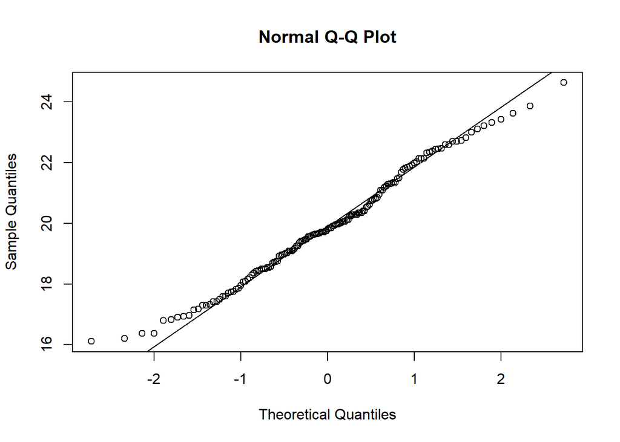

```r
qqnorm(Temperatura)
qqline(Temperatura)
```

```r
## Donde están los datos anómalos?
summary(temper)
```

```
##  Estacion   Temperatura    Precipitacion
##  A   :52   Min.   :16.11   Min.   :182.2
##  B   :52   1st Qu.:18.55   1st Qu.:276.5
##  C   :51   Median :19.79   Median :302.0
##  NA's: 1   Mean   :19.95   Mean   :304.5
##            3rd Qu.:21.21   3rd Qu.:336.2
##            Max.   :32.00   Max.   :441.7
##            NA's   :2
```

```r
detach(temper)
```